# Practical Machine Learning Course Project

Sachin Sharma

10/14/2021

# Importing Libraries

```r
library(dplyr)
```

```r
library(ggplot2)
library(tinytex)
library(naniar)
library(corrgram)
library(corrplot)
library(caret)
library(randomForest)
library(e1071)
library(gbm)
library(doParallel)
library(survival)
library(splines)
```

# Background

Using devices such as Jawbone Up, Nike FuelBand, and Fitbit it is now possible to collect a large amount of data about personal activity relatively inexpensively. These type of devices are part of the quantified self movement a group of enthusiasts who take measurements about themselves regularly to improve their health, to find patterns in their behavior, or because they are tech geeks. One thing that people regularly do is quantify how much of a particular activity they do, but they rarely quantify how well they do it. In this project, your goal will be to use data from accelerometers on the belt, forearm, arm, and dumbell of 6 participants. They were asked to perform barbell lifts correctly and incorrectly in 5 different ways. More information is available from the website here: http://groupware.les.inf.puc-rio.br/har (see the section on the Weight Lifting Exercise Dataset)."

# Data

The data for this project come from this source: http://groupware.les.inf.puc-rio.br/har. The information has been generously provided for use use in this cousera course by the authors, Velloso, E.; Bulling, A.; Gellersen, H.; Ugulino, W.; Fuks, H. They have allowed the use of their paper “Qualitative Activity Recognition of Weight Lifting Exercises. Proceedings of 4th International Conference in Cooperation with SIGCHI (Augmented Human ’13) . Stuttgart, Germany : ACM SIGCHI, 2013.

The training data for this project is available here:

https://d396qusza40orc.cloudfront.net/predmachlearn/pml-training.csv

The test data for this project is available here:

https://d396qusza40orc.cloudfront.net/predmachlearn/pml-testing.csv

# Steps Followed

### Data Wrangling

#### Removing NA values if any.

# Importing data

```r
train <- read.csv("train.csv")
test <- read.csv("test.csv")
head(train)
```

```
##   X user_name raw_timestamp_part_1 raw_timestamp_part_2   cvtd_timestamp
## 1 1  carlitos           1323084231               788290 05/12/2011 11:23
## 2 2  carlitos           1323084231               808298 05/12/2011 11:23
## 3 3  carlitos           1323084231               820366 05/12/2011 11:23
## 4 4  carlitos           1323084232               120339 05/12/2011 11:23
## 5 5  carlitos           1323084232               196328 05/12/2011 11:23
## 6 6  carlitos           1323084232               304277 05/12/2011 11:23
##   new_window num_window roll_belt pitch_belt yaw_belt total_accel_belt
## 1         no         11      1.41       8.07    -94.4                3
## 2         no         11      1.41       8.07    -94.4                3
## 3         no         11      1.42       8.07    -94.4                3
## 4         no         12      1.48       8.05    -94.4                3
## 5         no         12      1.48       8.07    -94.4                3
## 6         no         12      1.45       8.06    -94.4                3
##   kurtosis_roll_belt kurtosis_picth_belt kurtosis_yaw_belt skewness_roll_belt
```

[output cut: 251 more lines]

## Checking the structure of the data

```r
str(train)
```

```
## 'data.frame':    19622 obs. of  160 variables:
##  $ X                       : int  1 2 3 4 5 6 7 8 9 10 ...
##  $ user_name               : chr  "carlitos" "carlitos" "carlitos" "carlitos" ...
##  $ raw_timestamp_part_1    : int  1323084231 1323084231 1323084231 1323084232 1323084232 1323084232 1323084232 1323084232 1323084232 1323084232 ...
##  $ raw_timestamp_part_2    : int  788290 808298 820366 120339 196328 304277 368296 440390 484323 484434 ...
##  $ cvtd_timestamp          : chr  "05/12/2011 11:23" "05/12/2011 11:23" "05/12/2011 11:23" "05/12/2011 11:23" ...
##  $ new_window              : chr  "no" "no" "no" "no" ...
##  $ num_window              : int  11 11 11 12 12 12 12 12 12 12 ...
##  $ roll_belt               : num  1.41 1.41 1.42 1.48 1.48 1.45 1.42 1.42 1.43 1.45 ...
##  $ pitch_belt              : num  8.07 8.07 8.07 8.05 8.07 8.06 8.09 8.13 8.16 8.17 ...
##  $ yaw_belt                : num  -94.4 -94.4 -94.4 -94.4 -94.4 -94.4 -94.4 -94.4 -94.4 -94.4 ...
##  $ total_accel_belt        : int  3 3 3 3 3 3 3 3 3 3 ...
##  $ kurtosis_roll_belt      : chr  "" "" "" "" ...
##  $ kurtosis_picth_belt     : chr  "" "" "" "" ...
##  $ kurtosis_yaw_belt       : chr  "" "" "" "" ...
```

[output cut: 86 more lines]

# Checking the missing values in the data with the help of following methods :

```r
sum(is.na(train))
```

```
## [1] 1287472
```

```r
lapply(train, function(x)sum(is.na(x)))
```

[output not shown]

[output cut: 424 more lines]

[output not shown]

# To visualise the data , we will break the data in 8 equal data sets, which are as follows :

```r
ncol(train)
```

```
## [1] 160
```

```r
train_1 <- subset(train, select = c(1:20))

train_2 <-subset(train, select = c(21:40))

train_3 <- subset(train, select = c(41:60))

train_4 <- subset(train, select = c(61:80))

train_5 <- subset(train, select = c(81:100))
train_6 <- subset(train, select = c(101:120))
train_7 <- subset(train, select = c(121:140))
train_8 <- subset(train, select = c(141:160))
```

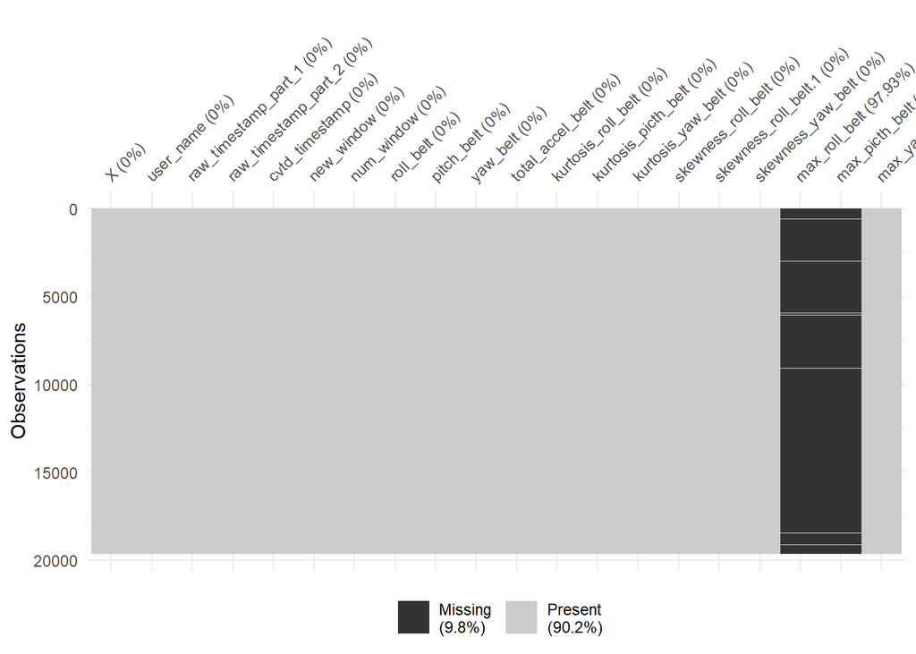

```r
vis_miss(train_1)
```

```r
sapply(train_1, function(x)sum(is.na(x)))
```

```
##                    X            user_name raw_timestamp_part_1
##                    0                    0                    0
## raw_timestamp_part_2       cvtd_timestamp           new_window
##                    0                    0                    0
##           num_window            roll_belt           pitch_belt
##                    0                    0                    0
##             yaw_belt     total_accel_belt   kurtosis_roll_belt
##                    0                    0                    0
##  kurtosis_picth_belt    kurtosis_yaw_belt   skewness_roll_belt
##                    0                    0                    0
## skewness_roll_belt.1    skewness_yaw_belt        max_roll_belt
##                    0                    0                19216
##       max_picth_belt         max_yaw_belt
##                19216                    0
```

```r
# need to drop max_pitch_belt , max_roll_belt
```

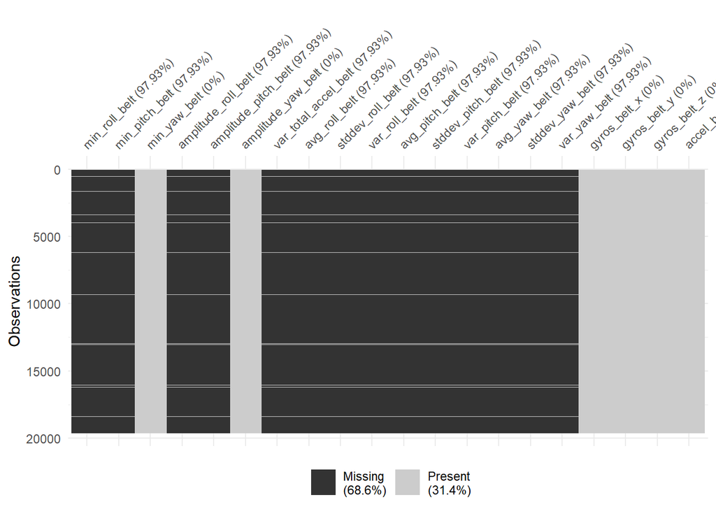

```r
vis_miss(train_2)
```

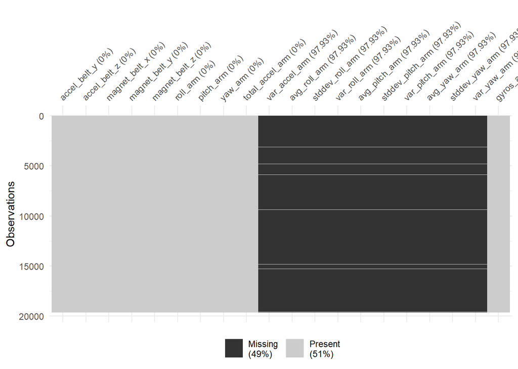

```r
vis_miss(train_3)
```

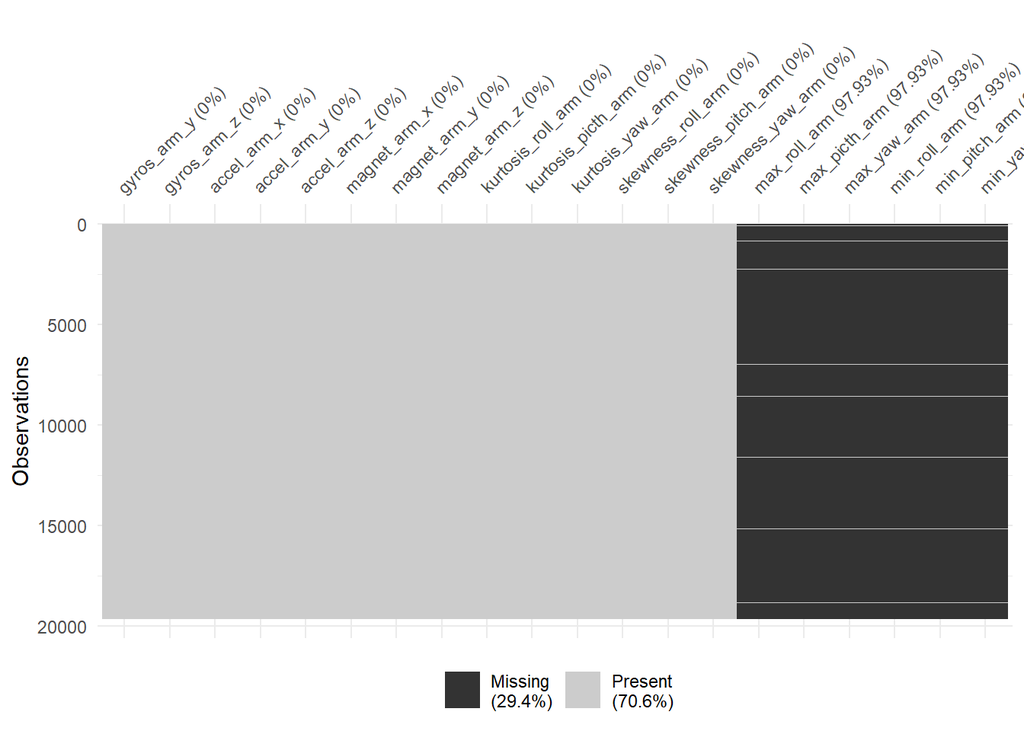

```r
vis_miss(train_4)
```

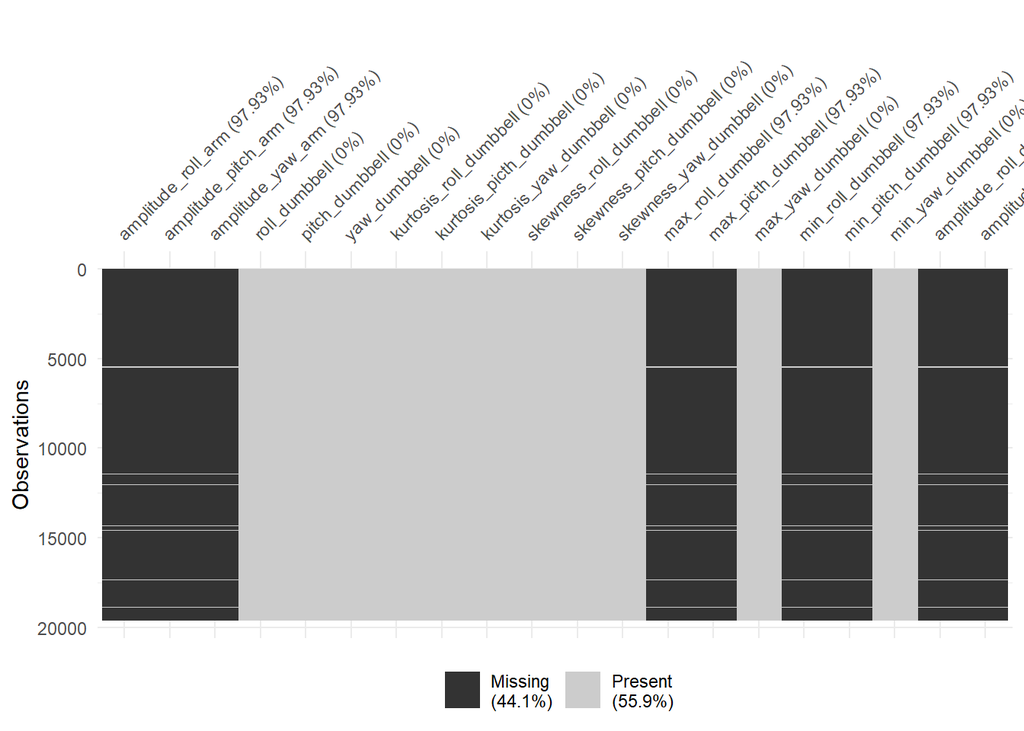

```r
vis_miss(train_5)
```

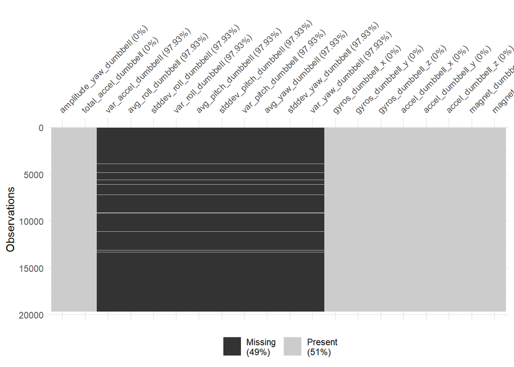

```r
vis_miss(train_6)
```

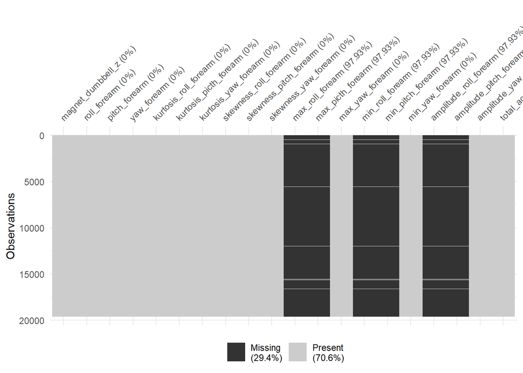

```r
vis_miss(train_7)
```

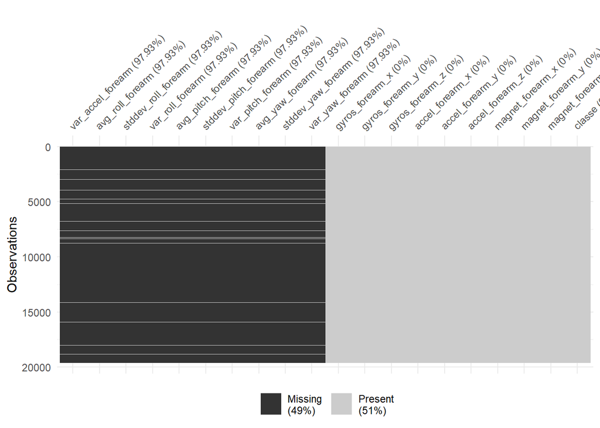

```r
vis_miss(train_8)
```